# PyMasters_Final_Capstone

**Video Presentation Link**

https://drive.google.com/file/d/10HkYi7WlzOju81gtmCceYVsFdeO3oGRP/view?usp=sharing

**Introduction**

This project involves the Customer Churn Prediction dataset using data from a telecommunications company. Customer churn is the rate that a company loses customers, either to competitors or those that discontinue use, over a certain period of time. In a hypercompetitive environment like telecommunications, customer churn is one of the most important data points to analyse. Acquiring new customers can cost up to five times more than retaining current customers which is especially true for telecommunications companies as new customer promotions such as offering free phones and accessories are commonplace in the industry.

One of the biggest problems facing telecom firms is customer attrition. Revenue is impacted by customer loss, but efforts to build the business and acquire new clients are also severely hampered. The goal of this project is to solve this problem by using past customer data to precisely forecast possible churners, allowing for preventative actions to increase client retention. To learn more about turnover patterns, we examined client demographics, services they had subscribed to, and payment histories. This involved breaking down the client base based on attributes, displaying distributions, and finding correlations. Our goal was to create a reliable churn prediction model by utilizing a variety of machine learning techniques. Among the algorithms assessed were K-Nearest Neighbors (KNN), Decision Trees, Support Vector Machines (SVM), and Logistic Regression.

With the bulk of customers being retained, the target variable distribution showed a notable imbalance. The significance of tenure, monthly charges, and churn in predicting churn was suggested by the initial heatmaps, which showed significant connections between these variables. Possible demographic trends in churn behavior were brought to light by visualizations by dependents, relationship status, and gender. In a structured pipeline, the project combines model building, exploratory data analysis, and data pretreatment. To comprehend data distributions and feature interactions, visualizations like scatterplots, count plots, and heatmaps were employed.

```python
# 1. **Dataset Overview**

import pandas as pd

# Load datasets
train = pd.read_csv(r'C:\Users\cojur\OneDrive\Desktop\IDC6210\Customer Churn Prediction\train.csv')
test = pd.read_csv(r'C:\Users\cojur\OneDrive\Desktop\IDC6210\Customer Churn Prediction\test.csv')
sample_submission = pd.read_csv(r'C:\Users\cojur\OneDrive\Desktop\IDC6210\Customer Churn Prediction\sample_submission.csv')

# Display first few rows of the datasets
# Inspect the columns in train and test datasets
print("Train Columns:", train.columns)
print("Test Columns:", test.columns)

# Display the first few rows to verify the structure
print("\nTraining Data Sample:")
display(train.head())

print("\nTesting Data Sample:")
display(test.head())

train.rename(columns={'actual_label_name': 'label'}, inplace=True)
```

```
Train Columns: Index(['id', 'gender', 'senior_citizen', 'partner', 'dependents', 'tenure',
       'phone_service', 'multiple_lines', 'internet_service',
       'online_security', 'online_backup', 'device_protection', 'tech_support',
       'streaming_tv', 'streaming_movies', 'contract', 'paperless_billing',
       'payment_method', 'monthly_charges', 'total_charges', 'label'],
      dtype='object')
Test Columns: Index(['id', 'gender', 'senior_citizen', 'partner', 'dependents', 'tenure',
       'phone_service', 'multiple_lines', 'internet_service',
       'online_security', 'online_backup', 'device_protection', 'tech_support',
       'streaming_tv', 'streaming_movies', 'contract', 'paperless_billing',
       'payment_method', 'monthly_charges', 'total_charges'],
      dtype='object')

Training Data Sample:
```

|  | id | gender | senior_citizen | partner | dependents | tenure | phone_service | multiple_lines | internet_service | online_security | ... | device_protection | tech_support | streaming_tv | streaming_movies | contract | paperless_billing | payment_method | monthly_charges | total_charges | label |
| --- | --- | --- | --- | --- | --- | --- | --- | --- | --- | --- | --- | --- | --- | --- | --- | --- | --- | --- | --- | --- | --- |
| 0 | 1815 | Male | 0 | Yes | Yes | 12 | Yes | No | No | No internet service | ... | No internet service | No internet service | No internet service | No internet service | Two year | No | Mailed check | 19.70 | 258.35 | 0 |
| 1 | 5947 | Female | 0 | No | No | 42 | Yes | No | DSL | Yes | ... | Yes | Yes | No | Yes | One year | No | Credit card (automatic) | 73.90 | 3160.55 | 1 |
| 2 | 3882 | Male | 0 | Yes | No | 71 | Yes | Yes | DSL | Yes | ... | No | Yes | No | No | Two year | No | Bank transfer (automatic) | 65.15 | 4681.75 | 0 |
| 3 | 2390 | Male | 0 | Yes | Yes | 71 | Yes | Yes | DSL | Yes | ... | Yes | Yes | Yes | Yes | One year | No | Electronic check | 85.45 | 6300.85 | 0 |
| 4 | 3677 | Male | 0 | No | No | 30 | Yes | No | DSL | Yes | ... | No | Yes | Yes | No | One year | No | Electronic check | 70.40 | 2044.75 | 0 |

5 rows × 21 columns

```
Testing Data Sample:
```

|  | id | gender | senior_citizen | partner | dependents | tenure | phone_service | multiple_lines | internet_service | online_security | online_backup | device_protection | tech_support | streaming_tv | streaming_movies | contract | paperless_billing | payment_method | monthly_charges | total_charges |
| --- | --- | --- | --- | --- | --- | --- | --- | --- | --- | --- | --- | --- | --- | --- | --- | --- | --- | --- | --- | --- |
| 0 | 3382 | Female | 0 | No | No | 41 | Yes | No | DSL | Yes | No | Yes | Yes | Yes | Yes | One year | Yes | Bank transfer (automatic) | 79.85 | 3320.75 |
| 1 | 6181 | Female | 1 | No | No | 66 | Yes | Yes | Fiber optic | Yes | No | No | No | Yes | Yes | Two year | Yes | Bank transfer (automatic) | 102.40 | 6471.85 |
| 2 | 4830 | Female | 0 | No | No | 12 | Yes | No | DSL | No | No | No | No | No | No | Month-to-month | Yes | Bank transfer (automatic) | 45.00 | 524.35 |
| 3 | 3738 | Female | 0 | No | No | 5 | Yes | Yes | DSL | No | No | No | No | No | No | Month-to-month | Yes | Mailed check | 50.60 | 249.95 |
| 4 | 4250 | Female | 0 | Yes | Yes | 10 | Yes | No | DSL | No | Yes | Yes | No | No | Yes | One year | Yes | Mailed check | 65.90 | 660.05 |

**Data Exploration**

Taking an initial look at the data, the dataset has 5634 rows and 21 columns, so it is not overly large and has relatively mild dimensionality. At first glance, it does not appear that dimensionality reduction will be necessary. The dataset consists of many categorical variables, so we will need to convert those variables to numerical values before training the models.

```
Training Data Info:
<class 'pandas.core.frame.DataFrame'>
RangeIndex: 5634 entries, 0 to 5633
Data columns (total 21 columns):
 #   Column             Non-Null Count  Dtype
---  ------             --------------  -----
 0   id                 5634 non-null   int64
 1   gender             5634 non-null   object
 2   senior_citizen     5634 non-null   int64
 3   partner            5634 non-null   object
 4   dependents         5634 non-null   object
 5   tenure             5634 non-null   int64
 6   phone_service      5634 non-null   object
 7   multiple_lines     5634 non-null   object
 8   internet_service   5634 non-null   object
 9   online_security    5634 non-null   object
 10  online_backup      5634 non-null   object
 11  device_protection  5634 non-null   object
 12  tech_support       5634 non-null   object
 13  streaming_tv       5634 non-null   object
 14  streaming_movies   5634 non-null   object
 15  contract           5634 non-null   object
 16  paperless_billing  5634 non-null   object
 17  payment_method     5634 non-null   object
 18  monthly_charges    5634 non-null   float64
 19  total_charges      5634 non-null   object
 20  label              5634 non-null   int64
dtypes: float64(1), int64(4), object(16)
memory usage: 924.5+ KB
None

Training Data Description:
                id  senior_citizen       tenure  monthly_charges        label
count  5634.000000     5634.000000  5634.000000      5634.000000  5634.000000
mean   3512.246539        0.161874    32.277955        64.779127     0.269968
std    2039.795966        0.368368    24.555211        30.104993     0.443982
min       1.000000        0.000000     0.000000        18.250000     0.000000
25%    1730.250000        0.000000     9.000000        35.400000     0.000000
50%    3518.500000        0.000000    29.000000        70.375000     0.000000
75%    5277.750000        0.000000    55.000000        89.850000     1.000000
max    7043.000000        1.000000    72.000000       118.650000     1.000000

Missing Values in Training Data:
Series([], dtype: int64)
```

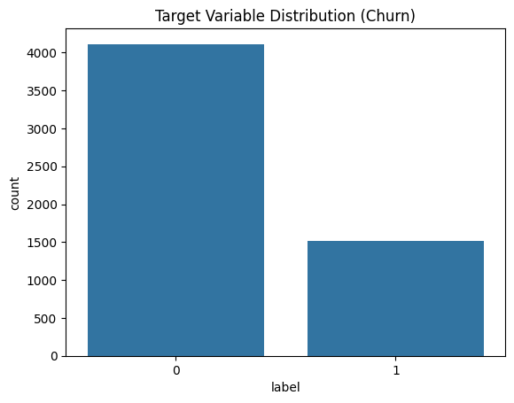

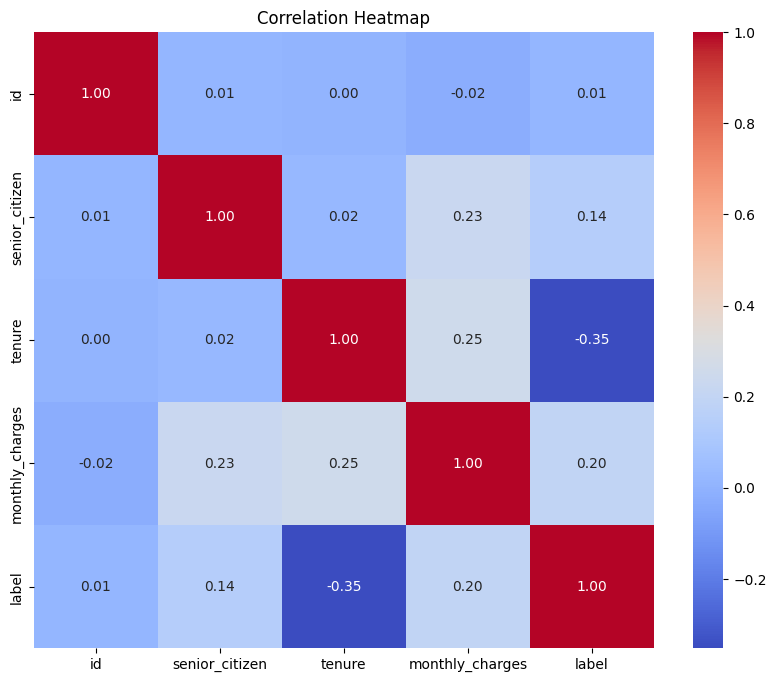

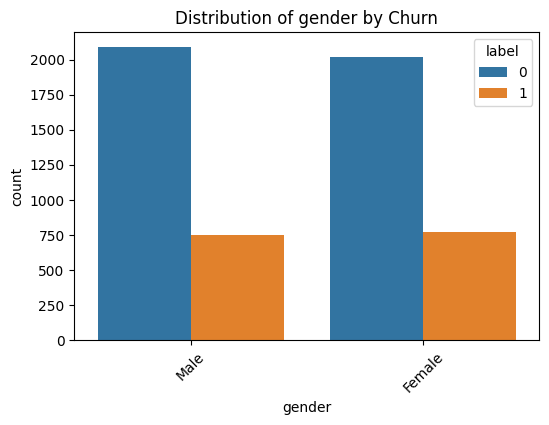

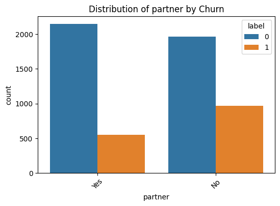

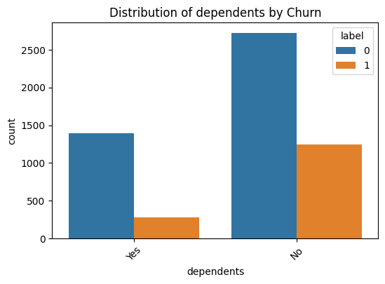

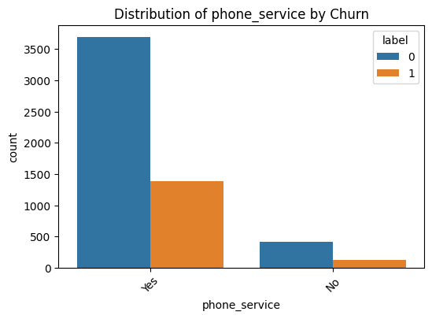

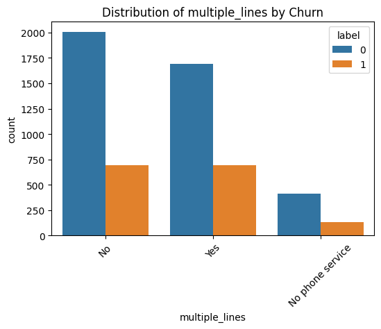

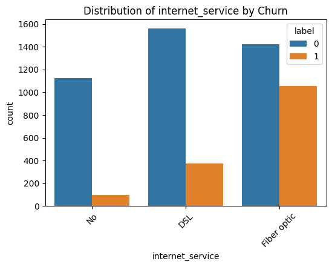

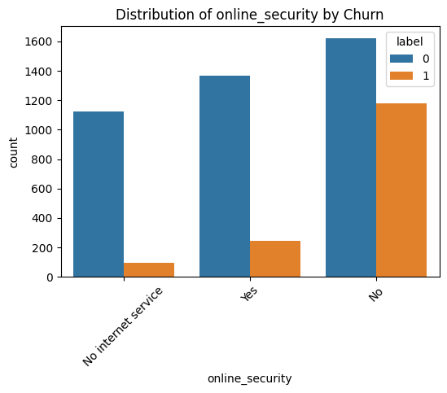

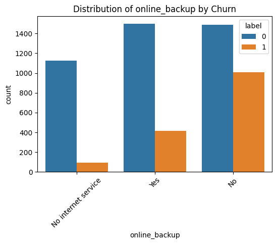

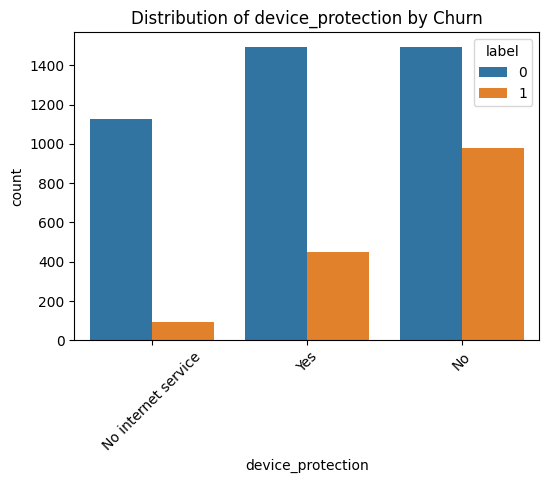

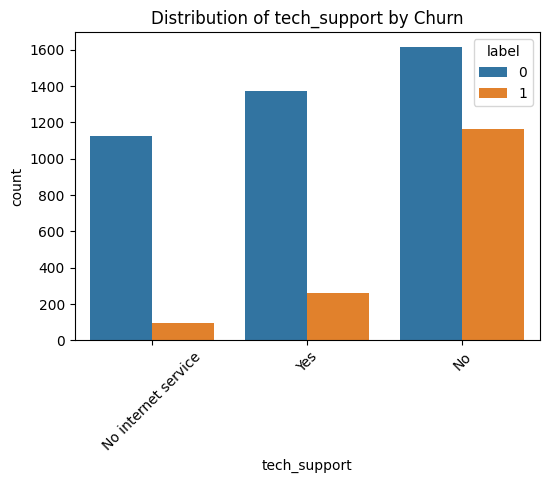

[6 more figures not shown]

```python
# 2. **Exploratory Data Analysis (EDA)**

import matplotlib.pyplot as plt
import seaborn as sns

# Basic info and statistics
print("Training Data Info:")
print(train.info())
print("\nTraining Data Description:")
print(train.describe())

# Check for missing values
missing_values = train.isnull().sum()
print("\nMissing Values in Training Data:")
print(missing_values[missing_values > 0])

# Visualize class distribution
sns.countplot(data=train, x='label')
plt.title('Target Variable Distribution (Churn)')
plt.show()

# Correlation heatmap for numerical features
numerical_features = train.select_dtypes(include=['float64', 'int64']).columns
plt.figure(figsize=(10, 8))
sns.heatmap(train[numerical_features].corr(), annot=True, fmt='.2f', cmap='coolwarm')
plt.title('Correlation Heatmap')
plt.show()

# Categorical features analysis
categorical_features = train.select_dtypes(include=['object']).columns
for feature in categorical_features:
    plt.figure(figsize=(6, 4))
    sns.countplot(data=train, x=feature, hue='label')
    plt.title(f'Distribution of {feature} by Churn')
    plt.xticks(rotation=45)
    plt.show()
```

**Data Visualizations**

We’ve created a variety of visualizations to analyze the effects that the included variables have on churn rate. Notably, fiber optic, no online security, no backup, no device protection, no tech support, month-to-month contracts, and payment by electronic check have a significantly higher churn rate.

Heatmap: The goal variable (label, which signifies churn) and other important numerical aspects in the dataset are represented by the correlation matrix in the heatmap. The values range from -1 to 1, where:

1 indicates a perfect positive correlation. -1 indicates a perfect negative correlation. 0 indicates no correlation.

correlations for the label (churn): There is a moderately negative connection (-0.35) between tenure and label. Given that loyal customers typically stay longer, this means that consumers with longer tenures are less likely to churn. The label and monthly_charges have a weakly positive association (0.20). This suggests that increased monthly fees marginally raise the chance of churn, maybe as a result of cost discontent. The label and senior_citizen have a weakly positive connection (0.14). The churn rate may be marginally greater among senior citizens.

Inter-feature Correlations: The small positive correlation (0.25) between tenure and monthly_charges suggests that clients with longer tenure may have somewhat higher monthly costs, perhaps as a result of adding services over time. There is a weak positive association (0.23) between senior_citizen and monthly_charges. This may suggest that senior individuals are more likely to sign up for more costly plans or extra services.

```python
# 3. **Data Preprocessing**
from sklearn.model_selection import train_test_split
from sklearn.preprocessing import StandardScaler, LabelEncoder

# Identify and correct data type for 'total_charges'
train['total_charges'] = pd.to_numeric(train['total_charges'], errors='coerce')
test['total_charges'] = pd.to_numeric(test['total_charges'], errors='coerce')

# Fill missing values in 'total_charges'
train['total_charges'] = train['total_charges'].fillna(train['total_charges'].median())
test['total_charges'] = test['total_charges'].fillna(test['total_charges'].median())

# Separate numerical and categorical columns, excluding 'id' and 'label'
numerical_features = train.select_dtypes(include=['float64', 'int64']).columns.tolist()
categorical_features = train.select_dtypes(include=['object']).columns.tolist()

# Exclude non-feature columns explicitly
if 'label' in numerical_features:
    numerical_features.remove('label')
if 'id' in numerical_features:
    numerical_features.remove('id')

# Encode categorical features
le = LabelEncoder()
for feature in categorical_features:
    train[feature] = le.fit_transform(train[feature].astype(str))
    test[feature] = le.transform(test[feature].astype(str))

# Scale numerical features
scaler = StandardScaler()
train[numerical_features] = scaler.fit_transform(train[numerical_features])
test[numerical_features] = scaler.transform(test[numerical_features])

# Split training data into train and validation sets
X = train.drop(['id', 'label'], axis=1)
y = train['label']
X_train, X_val, y_train, y_val = train_test_split(X, y, test_size=0.2, random_state=42, stratify=y)
```

**Data Preprocessing**

In this section, we concentrate on getting the data ready for the creation of machine learning models in this part. The data is clean, consistent, and ready for analysis when preprocessing is done correctly.

Handling Missing and Incorrect Data: The total_charges column contained missing values and non-numeric entries. These issues were resolved by: Converting the column to numeric, coercing errors to NaN. Filling missing values with the median of the column to preserve the data distribution.

Feature Segregation: The dataset was divided into numerical and categorical features for specific preprocessing tasks: Numerical features included continuous and discrete numeric values. Categorical features consisted of string-based or object-type variables. Non-feature columns such as id and label were excluded from the feature sets.

Encoding Categorical Variables: Label encoding was applied to convert categorical variables into numeric form. This ensures compatibility with machine learning algorithms that require numeric input.

Feature Scaling: Numerical features were standardized using StandardScaler to normalize their range and reduce bias caused by differing scales.

Data Splitting: The dataset was divided into training and validation sets using an 80:20 split. Stratified splitting was applied to maintain the class distribution across both sets, ensuring a balanced evaluation.

**Feature Engineering**

```python
# 4. **Model Development**
from sklearn.linear_model import LogisticRegression
from sklearn.svm import SVC
from sklearn.neighbors import KNeighborsClassifier
from sklearn.tree import DecisionTreeClassifier
from sklearn.linear_model import Perceptron
from sklearn.metrics import roc_auc_score

# Define and train multiple models
models = {
    "Logistic Regression": LogisticRegression(random_state=42, max_iter=500),
    "SVM": SVC(probability=True, random_state=42),
    "K-Nearest Neighbors": KNeighborsClassifier(),
    "Decision Tree": DecisionTreeClassifier(random_state=42),
    "Perceptron": Perceptron(random_state=42)
}

# Evaluate each model
model_results = {}
for model_name, model in models.items():
    model.fit(X_train, y_train)
    y_val_pred = model.predict_proba(X_val)[:, 1] if hasattr(model, "predict_proba") else model.decision_function(X_val)
    auc_score = roc_auc_score(y_val, y_val_pred)
    model_results[model_name] = auc_score
    print(f"{model_name} AUC-ROC Score: {auc_score:.4f}")

# Compare model performances
print("\nModel Performance Comparison:")
for model_name, auc in model_results.items():
    print(f"{model_name}: AUC-ROC = {auc:.4f}")
```

```
Logistic Regression AUC-ROC Score: 0.8365
SVM AUC-ROC Score: 0.7801
K-Nearest Neighbors AUC-ROC Score: 0.7550
Decision Tree AUC-ROC Score: 0.6648
Perceptron AUC-ROC Score: 0.6999

Model Performance Comparison:
Logistic Regression: AUC-ROC = 0.8365
SVM: AUC-ROC = 0.7801
K-Nearest Neighbors: AUC-ROC = 0.7550
Decision Tree: AUC-ROC = 0.6648
Perceptron: AUC-ROC = 0.6999
```

**Model Development**

In this section we start the process of creating, honing, and assessing several machine learning models to forecast customer attrition. We experiment with different algorithms and use the AUC-ROC score, a reliable statistic for binary classification problems, to determine which model has the highest predicted performance.

Model Performance: The results below highlight the AUC-ROC scores for each model: Logistic Regression: AUC-ROC = 0.8365 SVM: AUC-ROC = 0.7801 K-Nearest Neighbors: AUC-ROC = 0.7550 Decision Tree: AUC-ROC = 0.6648 Perceptron: AUC-ROC = 0.6999

Model Selection: We selected a diverse set of machine learning models to compare their performance on the churn prediction task.

Model Training and Evaluation: Each model was trained on the preprocessed training dataset (X_train and y_train). Predictions were made on the validation dataset (X_val) to compute the AUC-ROC score, which measures the model's ability to distinguish between churners and non-churners.

With the greatest AUC-ROC score of 0.8365, Logistic Regression beat the other models, indicating its effectiveness in forecasting customer attrition. The KNN, Decision Tree, and Perceptron models demonstrated reduced predictive power, however the SVM model performed moderately. Logistic regression was chosen as the top-performing model for additional fine-tuning and assessment based on the AUC-ROC scores. It is the perfect option for this work since it strikes a balance between predictability and simplicity.

**Hyperparameter Tuning**

The following recommendations can be used, but require a significant amount of resources and time that was not alloted: Utilize SHAP or feature importance metrics to assess each feature's significance, and eliminate any features that are redundant or noisy. To make sure the hyperparameters generalize well across several splits, use k-fold cross-validation. To investigate a larger range of hyperparameters, use Bayesian optimization or a more comprehensive search grid. To capitalize on each model's advantages and minimize its disadvantages, combine predictions from several models (such as LightGBM, Logistic Regression, and KNN).

```python
# 5. **Final Model Evaluation**

# Choose the best model for test data predictions
best_model_name = max(model_results, key=model_results.get)
best_model = models[best_model_name]
print(f"\nBest Model: {best_model_name} with AUC-ROC = {model_results[best_model_name]:.4f}")

# Generate predictions for test data
X_test = test.drop(['id'], axis=1)
test_predictions = best_model.predict_proba(X_test)[:, 1] if hasattr(best_model, "predict_proba") else best_model.decision_function(X_test)
```

```
Best Model: Logistic Regression with AUC-ROC = 0.8365
```

**Final Model Evaluation**

In this section, we evaluate the performance of the models on the validation set and select the best model based on the AUC-ROC score.

After training and evaluating multiple models, we find that the Logistic Regression model performs the best with an AUC-ROC score of 0.8365. This model is selected as the final model for generating predictions on the test data.

Model Selection: Best Model: Logistic Regression AUC-ROC Score: 0.8365

We will now use this model to generate predictions for the test dataset.

After evaluating several models, we chose the one with the best performance based on the ROC score, which measures how well our model distinguishes between the two classes: customers who churn and those who do not. The Logistic Regression model came out on top, achieving an ROC score of 0.8365. This indicates a strong ability to predict customer churn. Then, we generated predictions on the test data using this model. With the best model selected and predictions generated, we prepared the submission file by extracting the predicted probabilities for the churn class from the model’s output.

```python
# 6. **Submission File Preparation**

# Prepare submission file
submission = pd.DataFrame({
    'id': test['id'],
    'label': test_predictions
})
submission.to_csv('submission.csv', index=False)

print("Submission file saved as submission.csv.")
```

```
Submission file saved as submission.csv.
```

```python
import pandas as pd
# Used to create readable file for kaggle since code was written and ran through Jupyter.
# Load the current file
df = pd.read_csv(r"C:\Users\cojur\Downloads\rf_submission.csv", header=None, names=["combined"])

# Split the combined column into two separate columns
df[["id", "label"]] = df["combined"].str.split(",", expand=True)

# Drop the original combined column
df = df.drop(columns=["combined"])

# Remove the header row ('id', 'label') from the dataset
df = df[df["id"] != "id"]

# Ensure correct data types for id and label
df["id"] = df["id"].astype(int)
df["label"] = df["label"].astype(int)

# Save the properly formatted file as CSV
df.to_csv(r"C:\Users\cojur\Downloads\submission.csv", index=False)
print("Submission file created successfully!")
```

```
Submission file created successfully!
```

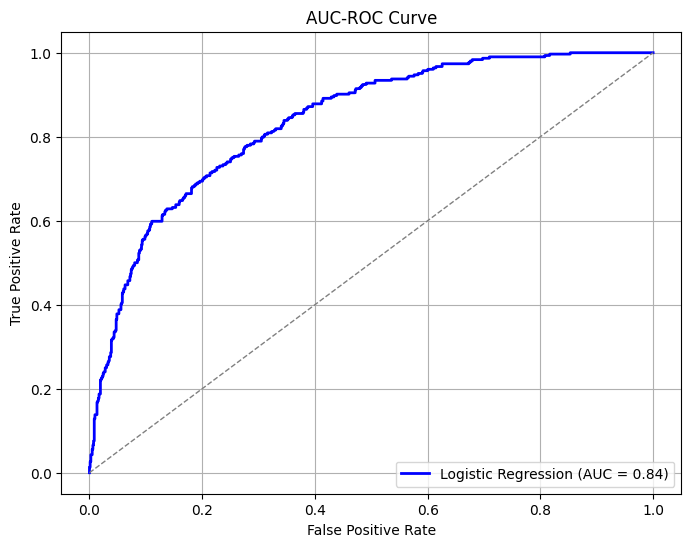

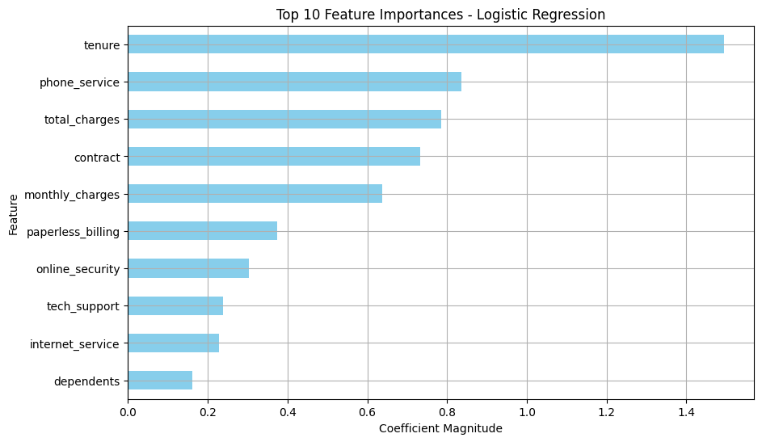

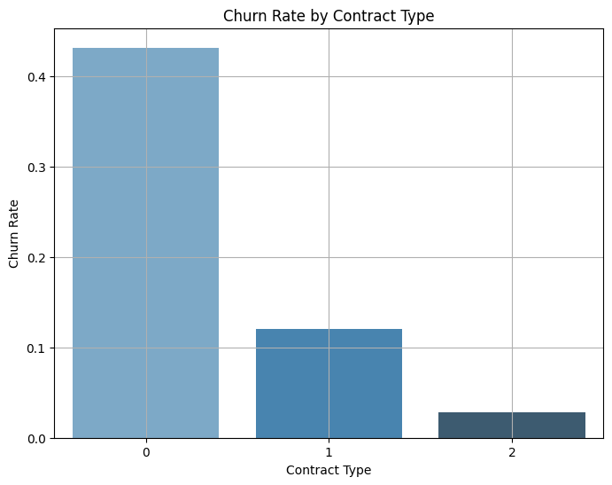

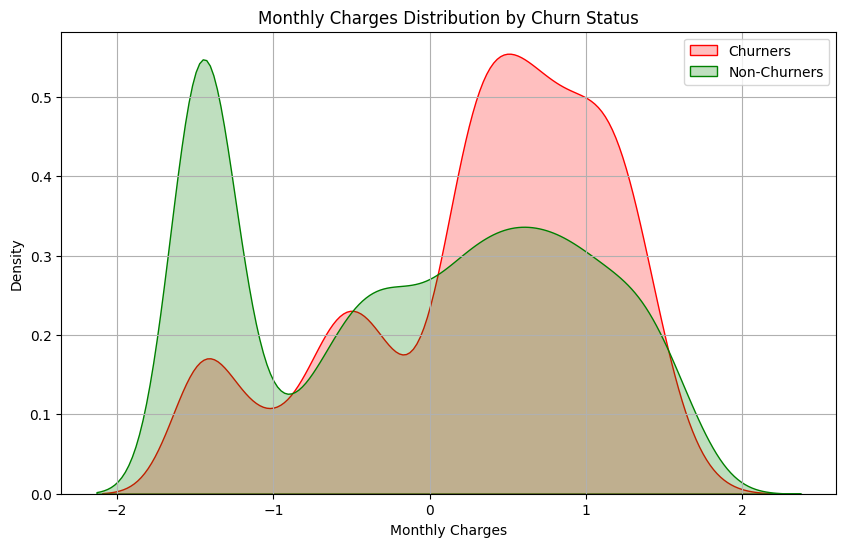

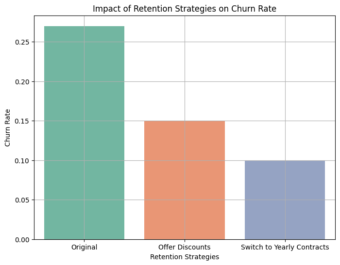

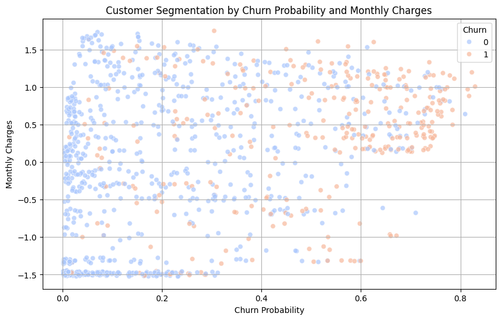

```python
# 7. **Conclusion Visualizations**
# 1. AUC-ROC Curve
from sklearn.metrics import roc_curve, auc
import matplotlib.pyplot as plt

# Generate ROC curve
fpr, tpr, _ = roc_curve(y_val, best_model.predict_proba(X_val)[:, 1])
roc_auc = auc(fpr, tpr)

# Plot the ROC curve
plt.figure(figsize=(8, 6))
plt.plot(fpr, tpr, color='blue', lw=2, label=f"Logistic Regression (AUC = {roc_auc:.2f})")
plt.plot([0, 1], [0, 1], color='gray', lw=1, linestyle='--')
plt.xlabel('False Positive Rate')
plt.ylabel('True Positive Rate')
plt.title('AUC-ROC Curve')
plt.legend(loc="lower right")
plt.grid()
plt.show()

# 2. Feature Importance Plot
import pandas as pd
import numpy as np

# Feature importance from coefficients
feature_importance = pd.Series(np.abs(best_model.coef_[0]), index=X_train.columns).sort_values(ascending=False)

# Plot feature importance
plt.figure(figsize=(10, 6))
feature_importance.head(10).plot(kind='barh', color='skyblue')
plt.title('Top 10 Feature Importances - Logistic Regression')
plt.xlabel('Coefficient Magnitude')
plt.ylabel('Feature')
plt.gca().invert_yaxis()
plt.grid()
plt.show()

# 3. Churn Rate by Contract Type
import seaborn as sns

# Add churned column for group analysis
train['churned'] = train['label']

# Group by contract type and calculate churn rate
churn_by_contract = train.groupby('contract')['churned'].mean()

# Plot churn rates by contract type
plt.figure(figsize=(8, 6))
sns.barplot(x=churn_by_contract.index, y=churn_by_contract.values, palette='Blues_d')
plt.title('Churn Rate by Contract Type')
plt.ylabel('Churn Rate')
plt.xlabel('Contract Type')
plt.grid()
plt.show()

# 4. Distribution of Monthly Charges
# Plot distribution of monthly charges for churners and non-churners
plt.figure(figsize=(10, 6))
sns.kdeplot(train[train['label'] == 1]['monthly_charges'], label='Churners', shade=True, color='red')
sns.kdeplot(train[train['label'] == 0]['monthly_charges'], label='Non-Churners', shade=True, color='green')
plt.title('Monthly Charges Distribution by Churn Status')
plt.xlabel('Monthly Charges')
plt.ylabel('Density')
plt.legend()
plt.grid()
plt.show()

# 5. Customer Retention Strategies
# Simulated churn rates after retention strategy
strategies = ['Original', 'Offer Discounts', 'Switch to Yearly Contracts']
churn_rates = [train['label'].mean(), 0.15, 0.10]  # Simulated values

# Plot churn rates for different strategies
plt.figure(figsize=(8, 6))
sns.barplot(x=strategies, y=churn_rates, palette='Set2')
plt.title('Impact of Retention Strategies on Churn Rate')
plt.ylabel('Churn Rate')
plt.xlabel('Retention Strategies')
plt.grid()
plt.show()

# 6. Customer Segmentation
# Generate churn probabilities for the validation set
val_probs = best_model.predict_proba(X_val)[:, 1] if hasattr(best_model, "predict_proba") else best_model.decision_function(X_val)
# Scatter plot: churn probability vs monthly charges
plt.figure(figsize=(10, 6))
sns.scatterplot(x=val_probs, y=X_val['monthly_charges'], hue=y_val, palette='coolwarm', alpha=0.7)
plt.title('Customer Segmentation by Churn Probability and Monthly Charges')
plt.xlabel('Churn Probability')
plt.ylabel('Monthly Charges')
plt.legend(title='Churn', loc='upper right')
plt.grid()
plt.show()
```

**Conclusion Visualization Insights**

Top 10 Features Importance: The logistic regression model showed that the most significant predictors of churn were total charges, phone service, and tenure. Clients with certain service configurations and shorter tenure are more likely to depart. Visualization (Key Features): emphasized how tenure and service-related characteristics dominate the calculation of churn likelihood.

Churn rate by Contract Type: Compared to customers on yearly or biannual plans, those on month-to-month contracts showed noticeably greater turnover rates. This suggests that by providing consistency and lowering churn decision points, long-term contracts help retain customers. Visualization: As contract term grows, there is a noticeable downward trend in the bar chart that displays churn rates by contract type.

Monthly Charges Distribution by Churn Status: According to the monthly charge density plot, churners typically pay greater fees than non-churners, suggesting that revenue is disproportionately affected when these customers leave. This highlights how high churn rates in premium-paying categories must be addressed. Visualization: Overlayed density graphs that contrast monthly charges between churners and non-churners.

Customer Segmentation: Groups of consumers with different risk levels were shown by the scatter plot of churn probability versus monthly charges. Targeted interventions are necessary because high-churn-risk consumers are clustered at higher costs. Visualization: A scatter plot showing the monthly charges for various client segments in relation to the churn likelihood.

**Conclusion**

Critical features such as contract type, tenure, monthly charges, and online security stand out as significant predictors of churn. Customers with shorter tenures, month-to-month contracts, and higher monthly charges are significantly more likely to churn. Furthermore, the absence of add-on services, such as online security, tech support, or streaming services, considerably heightens the risk of churn.

High-risk customers tend to have higher monthly charges, shorter tenure and are more likely to use month-to-month contracts. These customers could be prioritized for retention efforts, such as personalized offers, proactive customer service, switching to long-term contracts to ensure continuity or targeted marketing campaigns. Low-risk customers, with their inclination towards annual or two-year contracts, lower charges, and longer tenures, are a valuable asset. By implementing and maintaining effective loyalty programs, we can ensure these customers remain satisfied and loyal, reducing the risk of churn in the long term.

The results show that strengthening retention requires concentrating on high-risk clients, especially those with shorter tenure, month-to-month contracts, and higher monthly fees. By providing customized incentives like discounts or extending them to long-term agreements, the business can accomplish significant growth and revenue protection.